# Are Financial Market Returns Normal? What Breaks When You Assume They Are

SPY and seven sector-diverse stocks, 2011 to present

## Executive Summary

Daily returns for SPY and seven sector-diverse stocks are not normally distributed, and the gap has real consequences, not just a technical footnote. Every ticker shows significant excess kurtosis (SPY highest at 13.2, TSLA lowest at 4.7), and three independent normality tests reject the normal distribution for all 8 tickers by many orders of magnitude, easily surviving a Bonferroni correction; a 4-standard-deviation SPY day happens roughly 120 times more often than a normal distribution predicts. Volatility is not constant either: SPY’s annualized volatility spiked as high as 94% during the 2020 COVID crash, 7.6 times its 12.3% typical level, and a GARCH(1,1) model using only one day of memory (96% persistence) tracks that swing closely, something an iid-normal assumption rules out entirely. The consequence shows up directly in Value-at-Risk: a normal-distribution VaR model breaches its own 99% confidence threshold 1.8 to 2.6 times more often than it should, on every one of the 8 tickers, and for SPY specifically understates the 1-in-100-day loss on a $1M position by roughly 25%, or $5,752. An empirical (historical) VaR model does meaningfully better but is not perfect either, and Christoffersen’s test shows breaches cluster in time under both methods rather than landing independently, the same volatility-clustering signature from Sections 5 and 6 showing up again inside a risk model’s own failures.

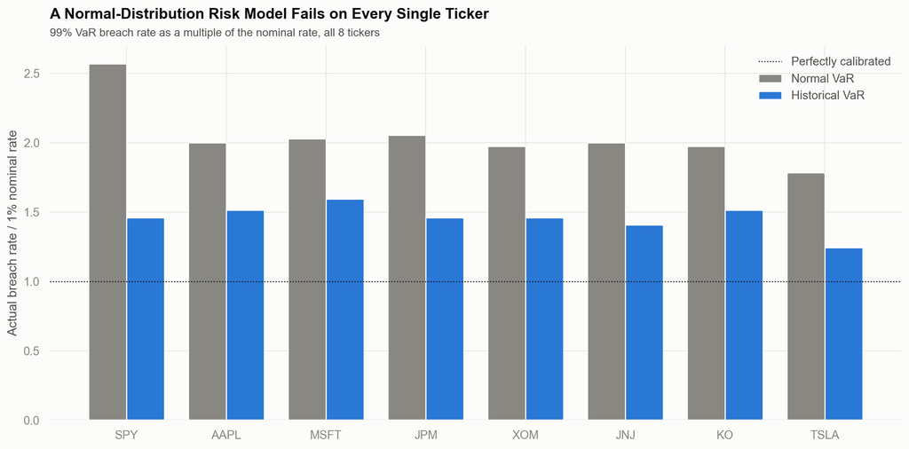

Figure 1: 99% VaR breach rate as a multiple of the 1% nominal rate, all 8 tickers

## 1 Introduction

This report asks a simple question: do daily returns for a major stock market index and a sector-diverse set of individual stocks look normally distributed, and what happens to models that assume they do. The data covers SPY, the S&P 500 index fund, alongside seven individual stocks chosen for sector spread rather than similarity: AAPL and MSFT (technology), JPM (financials), XOM (energy), JNJ (healthcare), KO (consumer staples), and TSLA (high-volatility growth). Daily prices run from January 2011 through the most recent trading day, roughly fifteen years, covering both calm periods and two sharp volatility episodes, the 2020 COVID crash and the 2022 rate-hiking cycle.

The analysis proceeds in stages. First, a visual pass at whether the return distributions look normal at a glance. Second, formal statistical tests of that question. Third, whether volatility is constant over time or clusters into calm and turbulent periods. Fourth, whether daily returns are independent of each other or carry statistical memory. Each of these has a direct consequence for risk models, and the final section quantifies that consequence for Value-at-Risk, a widely used measure of how much a position could lose in a single day.

## 2 Data

Prices come from Yahoo Finance via the `yfinance` package (Aroussi 2024), adjusted for splits and dividends. All 8 tickers have identical coverage: 3,952 trading days from 2011-01-03 to the most recent close, with no missing values in any series. Log returns are computed as the day-over-day change in log price, which leaves 3,951 return observations per ticker (the first day of the window has no prior price to compare against). The table below summarizes the daily log return distribution for each ticker before any shape or normality question is asked of it.

```python
summary_stats = (
    returns.groupby("ticker")["log_return"]
    .agg(n="count", mean="mean", std="std", min="min", max="max")
    .reindex(TICKERS)
    .reset_index()
)

style_table(summary_stats, formats={
    "n": "{:,.0f}",
    "mean": "{:.4%}",
    "std": "{:.4%}",
    "min": "{:.2%}",
    "max": "{:.2%}",
})
```

Table 1: Daily log return summary statistics by ticker

| ticker | n | mean | std | min | max |
| --- | --- | --- | --- | --- | --- |
| SPY | 3,951 | 0.0527% | 1.0737% | -11.59% | 9.99% |
| AAPL | 3,951 | 0.0895% | 1.7762% | -13.77% | 14.26% |
| MSFT | 3,951 | 0.0801% | 1.6548% | -15.95% | 14.42% |
| JPM | 3,951 | 0.0634% | 1.7102% | -16.21% | 16.56% |
| XOM | 3,951 | 0.0341% | 1.6028% | -13.04% | 11.94% |
| JNJ | 3,951 | 0.0483% | 1.0903% | -10.58% | 7.69% |
| KO | 3,951 | 0.0370% | 1.0915% | -10.17% | 6.28% |
| TSLA | 3,951 | 0.1355% | 3.5598% | -23.65% | 21.83% |

Before any autocorrelation or volatility analysis can be trusted, the return series themselves need to be stationary, meaning their statistical properties do not drift systematically over time. This is standard practice to check rather than assume. The Augmented Dickey-Fuller test (Dickey and Fuller 1979) does this by testing whether a series has a unit root (a tendency to wander rather than revert); rejecting that null hypothesis is evidence of stationarity.

**NoteWhat is the Augmented Dickey-Fuller test?**

A stationary series is one whose statistical properties, like its mean and variance, do not drift systematically over time. A series with a unit root instead tends to wander: today’s level depends heavily on yesterday’s level plus a shock that never fully fades, so shocks accumulate rather than dissipate. The test fits

$$\Delta y_t = \alpha + \beta y_{t-1} + \sum_{i=1}^{p} \phi_i \Delta y_{t-i} + \varepsilon_t$$

where $\Delta y_t = y_t - y_{t-1}$, and checks whether $\beta$ is significantly less than zero: the lagged-difference terms soak up any short-term autocorrelation so the test on $\beta$ isolates the unit-root question. A large negative test statistic and a small p-value reject the null of $\beta = 0$ (a unit root) and support stationarity.

```python
adf_results = []
for ticker in TICKERS:
    series = returns.loc[returns["ticker"] == ticker, "log_return"]
    stat, pvalue, *_ = adfuller(series, autolag="AIC")
    adf_results.append({"ticker": ticker, "adf_statistic": stat, "p_value": pvalue})

adf_table = pd.DataFrame(adf_results)

style_table(adf_table, formats={"adf_statistic": "{:.2f}", "p_value": "{:.4f}"})
```

Table 2: Augmented Dickey-Fuller stationarity test on daily log returns

| ticker | adf_statistic | p_value |
| --- | --- | --- |
| SPY | -14.25 | 0.0000 |
| AAPL | -21.01 | 0.0000 |
| MSFT | -22.18 | 0.0000 |
| JPM | -14.51 | 0.0000 |
| XOM | -14.38 | 0.0000 |
| JNJ | -20.28 | 0.0000 |
| KO | -13.85 | 0.0000 |
| TSLA | -63.82 | 0.0000 |

Every ticker rejects the unit-root null at any conventional threshold: even judged against a Bonferroni-adjusted threshold of 0.05 divided by 8 (0.00625), to account for running the same test 8 times, every p-value clears it by many orders of magnitude. All 8 log return series are treated as stationary for the rest of this report.

Before turning to statistical properties, it helps to see what the underlying, traded instrument actually looks like. The chart below shows SPY’s daily candles and trading volume over the last six months.

**NoteHow to read a candlestick chart**

Each candle summarizes one trading day. The thick body spans the day’s open and close: green means the close was higher than the open, red means it was lower. The thin wicks above and below the body mark the day’s high and low, the most extreme prices reached even if the price did not close there. The bars in the panel below show trading volume, the number of shares traded that day.

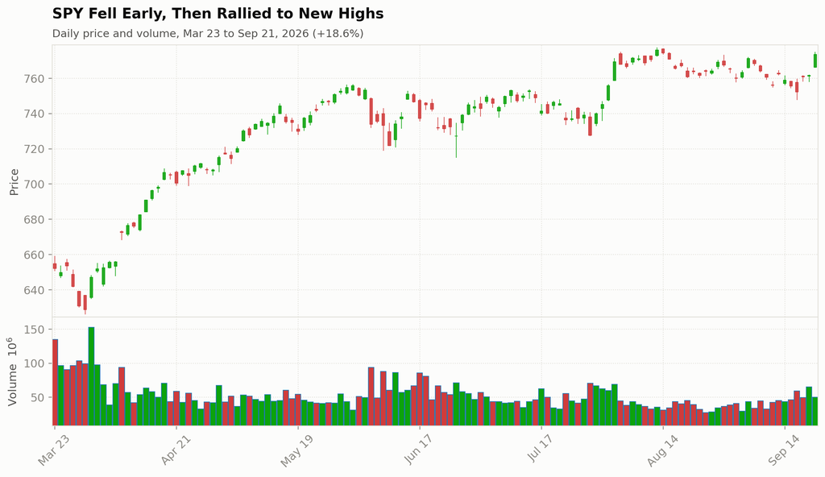

Figure 2: SPY daily price action and volume, last 6 months

```python
candle_df = spy_ohlcv.set_index("date").rename(
    columns={"open": "Open", "high": "High", "low": "Low", "close": "Close", "volume": "Volume"}
)

market_colors = mpf.make_marketcolors(
    up="#0ca30c", down="#d03b3b", edge="inherit", wick="inherit", volume="inherit"
)
candle_style = mpf.make_mpf_style(
    marketcolors=market_colors,
    facecolor=COLOR_SURFACE,
    figcolor=COLOR_SURFACE,
    gridcolor=COLOR_GRID,
    gridstyle=":",
    rc={
        "font.size": 11,
        "text.color": COLOR_SECONDARY_INK,
        "axes.labelcolor": COLOR_SECONDARY_INK,
        "axes.edgecolor": COLOR_GRID,
        "xtick.color": COLOR_MUTED,
        "ytick.color": COLOR_MUTED,
    },
)

fig, axlist = mpf.plot(
    candle_df, type="candle", volume=True, style=candle_style,
    figsize=(12, 6), tight_layout=True, returnfig=True,
)
add_title(axlist[0], "SPY Fell Early, Then Rallied to New Highs", "Daily price and volume, Mar 23 to Sep 21, 2026 (+18.6%)")
```

The next chart turns to the full ~15-year window and asks a simpler question: how did $100 invested in each of these 8 tickers actually grow over time. Because TSLA’s growth is an order of magnitude larger than the other 7 tickers, the y-axis uses a log scale; on a linear scale, TSLA’s line would flatten every other ticker into an indistinguishable band near zero.

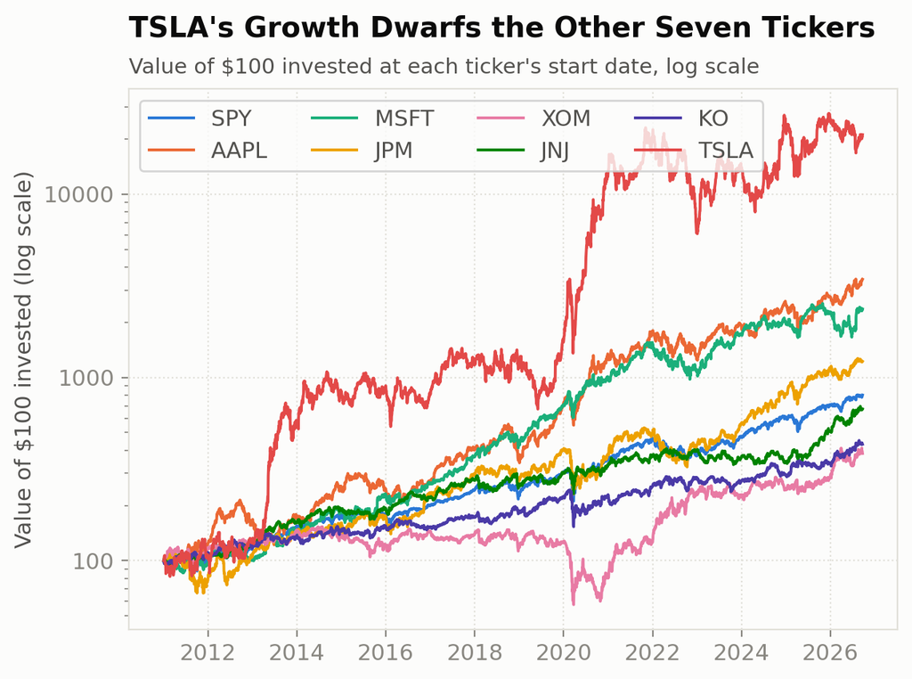

Figure 3: Normalized cumulative growth, indexed to 100 at the start date (log scale)

```python
wide_prices = prices.pivot(index="date", columns="ticker", values="adj_close")
normalized_growth = wide_prices / wide_prices.iloc[0] * 100

fig, ax = plt.subplots()
for ticker in TICKERS:
    ax.plot(normalized_growth.index, normalized_growth[ticker], color=TICKER_COLORS[ticker], linewidth=1.4, label=ticker)

ax.set_yscale("log")
ax.yaxis.set_major_formatter(mticker.ScalarFormatter())
ax.yaxis.set_minor_formatter(mticker.NullFormatter())
ax.set_ylabel("Value of $100 invested (log scale)")
ax.set_xlabel(None)
ax.legend(loc="upper left", ncol=4)
add_title(ax, "TSLA's Growth Dwarfs the Other Seven Tickers", "Value of $100 invested at each ticker's start date, log scale")
fig.tight_layout()
```

Finally, the sector spread behind these 8 tickers was chosen deliberately, not arbitrarily, so it is worth checking directly: are these return series actually distinct from each other, or do they move together closely enough that “8 tickers” is really just one story repeated 8 times. The heatmap below shows the pairwise correlation of daily log returns.

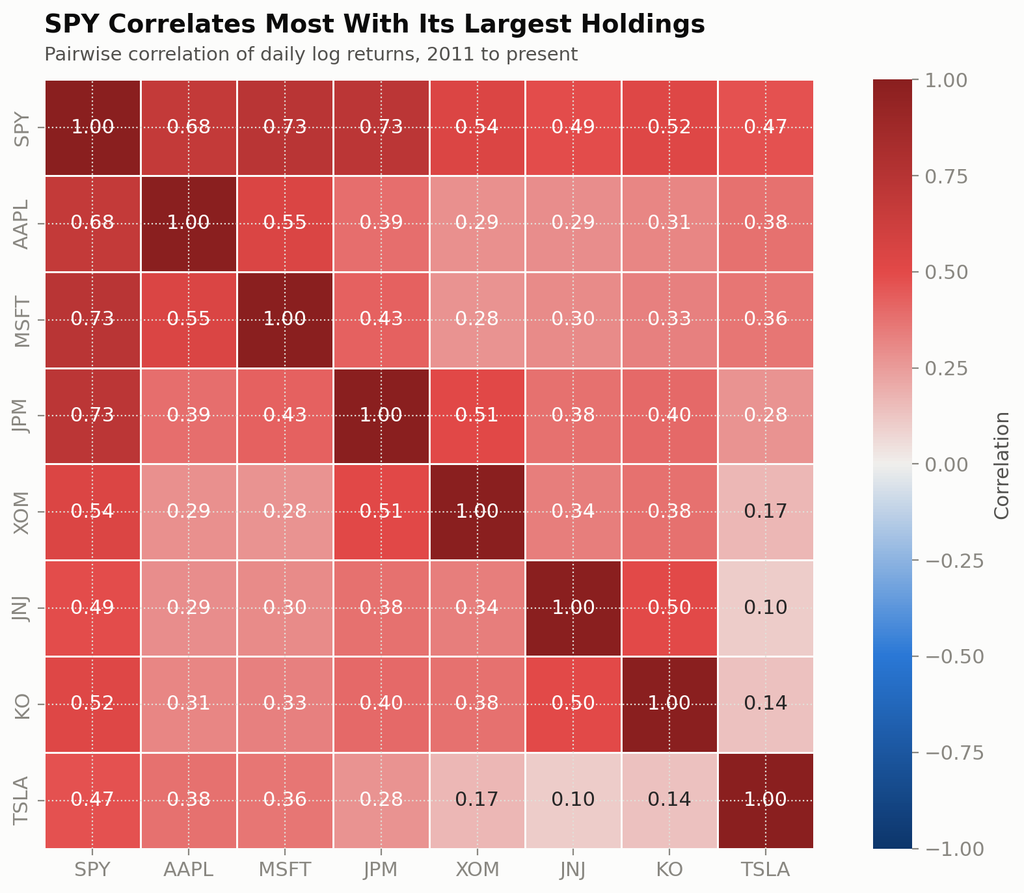

Figure 4: Pairwise correlation of daily log returns across all 8 tickers

```python
from matplotlib.colors import LinearSegmentedColormap

diverging_cmap = LinearSegmentedColormap.from_list("diverging_blue_red", DIVERGING_BLUE_RED)

corr_matrix = wide_prices.pct_change().apply(lambda x: np.log1p(x)).corr().reindex(index=TICKERS, columns=TICKERS)

fig, ax = plt.subplots(figsize=(9.5, 7))
sns.heatmap(
    corr_matrix, annot=True, fmt=".2f", cmap=diverging_cmap, vmin=-1, vmax=1,
    center=0, square=True, linewidths=1, linecolor=COLOR_SURFACE,
    cbar_kws={"label": "Correlation"}, ax=ax,
)
ax.set_xlabel(None)
ax.set_ylabel(None)
add_title(ax, "SPY Correlates Most With Its Largest Holdings", "Pairwise correlation of daily log returns, 2011 to present")
fig.tight_layout()
```

SPY’s three strongest correlations are with MSFT (0.73), JPM (0.73), and AAPL (0.68), consistent with SPY being a market-cap-weighted index that these large-cap names have real weight in. The weakest pair in the entire matrix is JNJ and TSLA (0.10), a healthcare staple and a high-volatility growth stock, about as different as two equities get. Averaged across its correlation with the other 7 tickers, TSLA sits lowest at 0.27, well below SPY’s average of 0.59, so TSLA is the ticker that moves most independently of the rest of the set. No pair is close to perfectly correlated, confirming the sector spread is doing real work rather than sampling eight versions of the same underlying signal.

## 3 Distributional Shape at a Glance

Before running any formal test, it is worth asking what a return distribution looks like next to a normal curve with the same center and spread. Two properties matter most here: skewness, whether the distribution leans to one side, and kurtosis, how much probability sits in the tails and the peak compared to a normal distribution. D’Agostino’s skewness test and kurtosis test (D’Agostino and Pearson 1973) give an inferential read on both, across all 8 tickers, before the fuller Jarque-Bera and Shapiro-Wilk treatment in the next section.

**NoteWhat do skewness and kurtosis measure?**

Skewness measures asymmetry: a symmetric distribution, like the normal, has zero skewness, a positive value means a longer right tail, a negative value means a longer left tail. Kurtosis measures how much probability sits in the tails and the peak relative to a normal distribution; the normal distribution has a kurtosis of 3, so this report reports “excess kurtosis” (kurtosis minus 3), where zero matches a normal distribution and a positive value means fatter tails and a sharper peak than normal. D’Agostino’s skewness test and kurtosis test each check whether the sample’s value on that one property is far enough from what a normal distribution would produce to rule out normality on that property alone.

```python
shape_results = []
for ticker in TICKERS:
    series = returns.loc[returns["ticker"] == ticker, "log_return"]
    skew_stat, skew_p = stats.skewtest(series)
    kurt_stat, kurt_p = stats.kurtosistest(series)
    shape_results.append({
        "ticker": ticker,
        "excess_kurtosis": stats.kurtosis(series),
        "skewtest_p": skew_p,
        "kurtosistest_p": kurt_p,
    })

shape_table = pd.DataFrame(shape_results)

style_table(shape_table, formats={"excess_kurtosis": "{:.2f}", "skewtest_p": "{:.4f}", "kurtosistest_p": "{:.4f}"})
```

Table 3: D’Agostino skewness and kurtosis tests on daily log returns

| ticker | excess_kurtosis | skewtest_p | kurtosistest_p |
| --- | --- | --- | --- |
| SPY | 13.18 | 0.0000 | 0.0000 |
| AAPL | 6.23 | 0.0000 | 0.0000 |
| MSFT | 8.92 | 0.4440 | 0.0000 |
| JPM | 10.31 | 0.0031 | 0.0000 |
| XOM | 6.58 | 0.0000 | 0.0000 |
| JNJ | 8.71 | 0.0000 | 0.0000 |
| KO | 8.90 | 0.0000 | 0.0000 |
| TSLA | 4.72 | 0.6118 | 0.0000 |

Every ticker’s excess kurtosis is positive, and the kurtosis test rejects normal-level kurtosis for all 8 at any conventional threshold, so the “fatter peak, fatter tails” shape is universal in this data. This section runs 16 tests (8 tickers x 2 properties), so the relevant Bonferroni-adjusted threshold is 0.05 divided by 16, or 0.003125, not the uncorrected 0.05: every kurtosis p-value clears it trivially. Skewness is a different story: only 6 of the 8 tickers (SPY, AAPL, JPM, XOM, JNJ, KO) show statistically significant skew, and one of those six is a genuine near-miss, JPM’s skew p-value of 0.00307 survives the 0.003125 threshold by less than 2%, closer to a coin flip than the other five tickers’ skew results. MSFT (p = 0.44) and TSLA (p = 0.61) do not reject the null of a symmetric distribution at any threshold. Kurtosis, not skewness, is the consistent shape violation here.

The chart below puts that kurtosis number in visual form for SPY specifically: its daily log returns against a normal curve fit with the exact same mean and standard deviation.

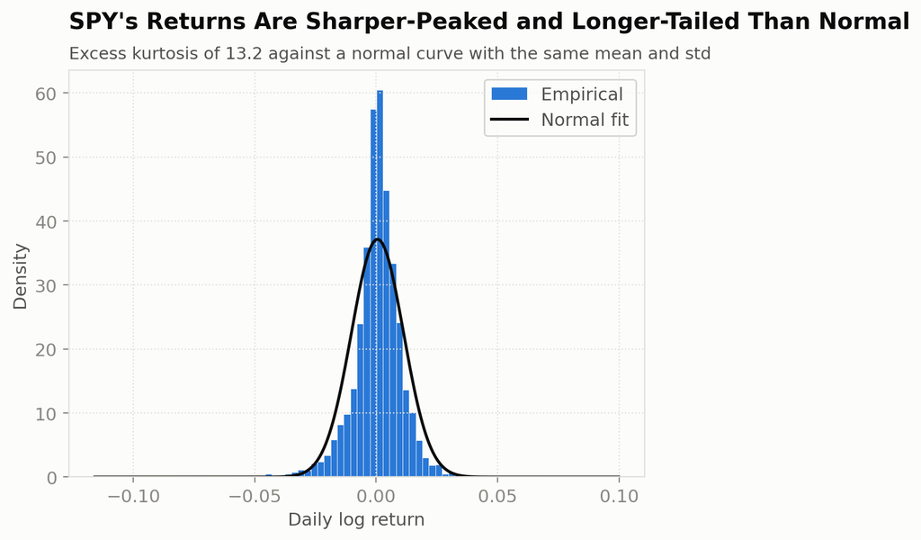

Figure 5: SPY daily log returns vs. a normal curve with the same mean and standard deviation

```python
spy_returns = returns.loc[returns["ticker"] == "SPY", "log_return"]

fig, ax = plt.subplots()
ax.hist(spy_returns, bins=80, density=True, color=SEQUENTIAL_RAMP[3], edgecolor=COLOR_SURFACE, linewidth=0.3, label="Empirical")
x_grid = np.linspace(spy_returns.min(), spy_returns.max(), 300)
ax.plot(x_grid, stats.norm.pdf(x_grid, spy_returns.mean(), spy_returns.std()), color=COLOR_PRIMARY_INK, linewidth=1.8, label="Normal fit")
ax.set_xlabel("Daily log return")
ax.set_ylabel("Density")
ax.legend(loc="upper right")
add_title(ax, "SPY's Returns Are Sharper-Peaked and Longer-Tailed Than Normal", "Excess kurtosis of 13.2 against a normal curve with the same mean and std")
fig.tight_layout()
```

The SPY-only chart above raises an obvious question: is this an SPY quirk, or does it hold across every ticker in the set. The small-multiples grid below repeats the same histogram-and-normal-curve treatment for all 8, each on its own independent axis so its individual shape is visible regardless of how its volatility compares to the others.

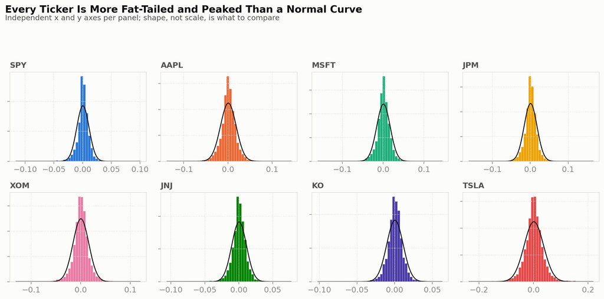

Figure 6: Daily log returns vs. fitted normal curve, all 8 tickers

```python
fig, axs = plt.subplots(2, 4, figsize=(12, 6))
for ax, ticker in zip(axs.flat, TICKERS):
    series = returns.loc[returns["ticker"] == ticker, "log_return"]
    ax.hist(series, bins=50, density=True, color=TICKER_COLORS[ticker], edgecolor=COLOR_SURFACE, linewidth=0.2)
    x_grid = np.linspace(series.min(), series.max(), 200)
    ax.plot(x_grid, stats.norm.pdf(x_grid, series.mean(), series.std()), color=COLOR_PRIMARY_INK, linewidth=1.2)
    ax.set_title(ticker, loc="left", fontsize=11, fontweight="bold", color=COLOR_SECONDARY_INK, pad=6)
    ax.set_yticklabels([])
    ax.set_ylabel(None)

fig.suptitle("Every Ticker Is More Fat-Tailed and Peaked Than a Normal Curve", x=0.01, ha="left", fontsize=14, fontweight="bold", color=COLOR_PRIMARY_INK)
fig.text(0.01, 0.93, "Independent x and y axes per panel; shape, not scale, is what to compare", fontsize=10.5, color=COLOR_SECONDARY_INK)
fig.tight_layout(rect=[0, 0, 1, 0.88])
```

A ridgeline plot makes the same comparison more compact, stacking all 8 distributions on a shared, standardized x-axis (each ticker’s returns converted to standard deviations from its own mean) so shape, and only shape, is what differs between rows.

**NoteHow to read a ridgeline plot**

Each row is a separate density curve, a smoothed version of a histogram, for one ticker’s return distribution, stacked so all 8 can be compared without an eight-color legend-heavy overlay. Taller and narrower means more of that ticker’s returns cluster tightly around its center; curves that stay visibly above zero further out along the x-axis before flattening mean more extreme values occur, even if rarely. Overlap between rows is intentional, it is what makes the stack compact, not a sign anything is misaligned.

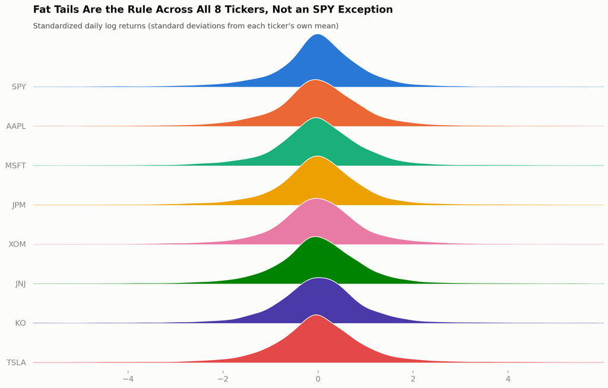

Figure 7: Standardized daily log returns for all 8 tickers

```python
returns_ridgeline = returns.copy()
returns_ridgeline["standardized_return"] = returns_ridgeline.groupby("ticker")["log_return"].transform(lambda x: (x - x.mean()) / x.std())
returns_ridgeline["ticker"] = pd.Categorical(returns_ridgeline["ticker"], categories=TICKERS, ordered=True)

fig, axes = joypy.joyplot(
    returns_ridgeline, by="ticker", column="standardized_return",
    color=[TICKER_COLORS[t] for t in TICKERS],
    figsize=(12, 8), overlap=0.7, x_range=[-6, 6], grid=False,
    linecolor=COLOR_SURFACE, linewidth=1,
)
add_title(axes[0], "Fat Tails Are the Rule Across All 8 Tickers, Not an SPY Exception", "Standardized daily log returns (standard deviations from each ticker's own mean)")
fig.subplots_adjust(top=0.88)
```

Both charts above show peakedness and tail weight, but neither one quantifies how much more often an extreme move actually happens than a normal distribution would predict. The chart below answers that directly for SPY: the probability of a daily move exceeding a given number of standard deviations, empirical against normal-implied, on a log scale so the gap at the extremes is visible instead of compressed to zero.

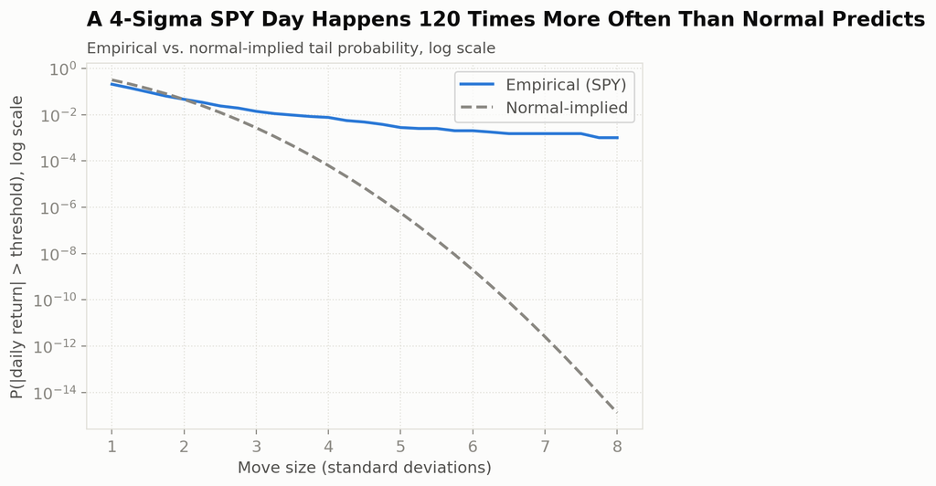

Figure 8: SPY: empirical vs. normal-implied probability of a daily move exceeding N standard deviations

```python
spy_z = (spy_returns - spy_returns.mean()) / spy_returns.std()
thresholds = np.arange(1, 8.01, 0.25)
empirical_p = [np.mean(spy_z.abs() > t) for t in thresholds]
normal_p = [2 * (1 - stats.norm.cdf(t)) for t in thresholds]

fig, ax = plt.subplots()
ax.plot(thresholds, empirical_p, color=TICKER_COLORS["SPY"], linewidth=2, label="Empirical (SPY)")
ax.plot(thresholds, normal_p, color=COLOR_MUTED, linewidth=2, linestyle="--", label="Normal-implied")
ax.set_yscale("log")
ax.set_xlabel("Move size (standard deviations)")
ax.set_ylabel("P(|daily return| > threshold), log scale")
ax.legend(loc="upper right")
add_title(ax, "A 4-Sigma SPY Day Happens 120 Times More Often Than Normal Predicts", "Empirical vs. normal-implied tail probability, log scale")
fig.tight_layout()
```

At 2 standard deviations the empirical and normal-implied probabilities are close, 4.6% against 4.5%. The gap opens fast after that: at 4 standard deviations, SPY’s actual probability of a move that large is 120 times what a normal distribution would predict, and at 5 standard deviations the ratio is roughly 4,900 times. The single most extreme day in the entire 15-year window is 2020-03-16, a -11.6% day at the height of the COVID crash, a -10.8 standard deviation move that a normal distribution would predict roughly once every 10^26 trading days, which is to say, never.

## 4 Formal Normality Tests

Section 3 built a visual and light inferential case that these returns are not normal. This section runs three formal, widely used normality tests on all 8 tickers: Jarque-Bera (Jarque and Bera 1980), which tests skewness and kurtosis jointly; Shapiro-Wilk (Shapiro and Wilk 1965), which tests the full shape of the distribution and is generally considered one of the most powerful normality tests available; and Anderson-Darling (Anderson and Darling 1952), which weights deviations in the tails more heavily than the center, making it especially sensitive to exactly the kind of tail behavior Section 3 raised.

**NoteWhat do these three normality tests actually test?**

$$JB = \frac{n}{6}\left(S^2 + \frac{K^2}{4}\right)$$

```python
normality_results = []
for ticker in TICKERS:
    series = returns.loc[returns["ticker"] == ticker, "log_return"]
    jb_stat, jb_p = stats.jarque_bera(series)
    sh_stat, sh_p = stats.shapiro(series)
    ad_result = stats.anderson(series, dist="norm")
    ad_critical_1pct = ad_result.critical_values[-1]
    normality_results.append({
        "ticker": ticker,
        "jarque_bera": jb_stat,
        "jb_p": jb_p,
        "shapiro_w": sh_stat,
        "shapiro_p": sh_p,
        "anderson_darling": ad_result.statistic,
        "ad_critical_1pct": ad_critical_1pct,
        "rejects_at_1pct": "Yes" if ad_result.statistic > ad_critical_1pct else "No",
    })

normality_table = pd.DataFrame(normality_results)

style_table(normality_table, formats={
    "jarque_bera": "{:,.0f}", "jb_p": "{:.4f}",
    "shapiro_w": "{:.4f}", "shapiro_p": "{:.4f}",
    "anderson_darling": "{:.2f}", "ad_critical_1pct": "{:.3f}",
})
```

Table 4: Jarque-Bera, Shapiro-Wilk, and Anderson-Darling normality tests on daily log returns

| ticker | jarque_bera | jb_p | shapiro_w | shapiro_p | anderson_darling | ad_critical_1pct | rejects_at_1pct |
| --- | --- | --- | --- | --- | --- | --- | --- |
| SPY | 28,816 | 0.0000 | 0.8908 | 0.0000 | 73.14 | 1.091 | Yes |
| AAPL | 6,412 | 0.0000 | 0.9387 | 0.0000 | 41.96 | 1.091 | Yes |
| MSFT | 13,108 | 0.0000 | 0.9238 | 0.0000 | 45.96 | 1.091 | Yes |
| JPM | 17,520 | 0.0000 | 0.9100 | 0.0000 | 58.50 | 1.091 | Yes |
| XOM | 7,148 | 0.0000 | 0.9372 | 0.0000 | 44.20 | 1.091 | Yes |
| JNJ | 12,561 | 0.0000 | 0.9204 | 0.0000 | 46.27 | 1.091 | Yes |
| KO | 13,321 | 0.0000 | 0.9165 | 0.0000 | 48.33 | 1.091 | Yes |
| TSLA | 3,669 | 0.0000 | 0.9445 | 0.0000 | 41.63 | 1.091 | Yes |

A single p-value cannot show where a distribution departs from normal, only that it does. The QQ plot below shows SPY’s actual return quantiles against the quantiles a normal distribution would produce; departure from the diagonal reference line marks exactly where the mismatch happens.

**NoteHow to read a QQ plot**

A QQ (quantile-quantile) plot sorts the actual data from smallest to largest and plots each value against the value a normal distribution would be expected to produce at that same percentile. If the data were exactly normal, every point would fall on the diagonal reference line. Points curving away from the line at the low end mean the data’s smallest values are more extreme than normal predicts; points curving away at the high end mean the same for the largest values. Both ends bowing away, as they do here, is the QQ-plot signature of fat tails.

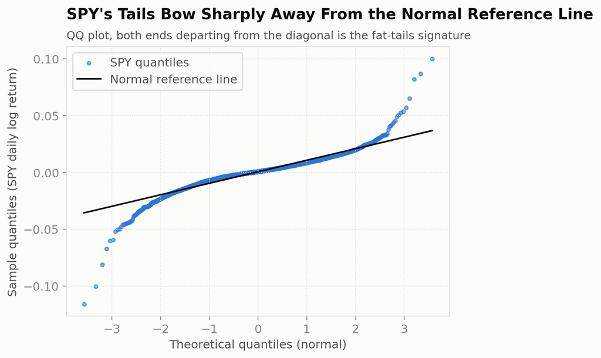

Figure 9: QQ plot of SPY daily log returns against a normal distribution

```python
(osm, osr), (slope, intercept, r) = stats.probplot(spy_returns, dist="norm")

fig, ax = plt.subplots()
ax.scatter(osm, osr, s=12, color=TICKER_COLORS["SPY"], alpha=0.6, label="SPY quantiles")
ax.plot(osm, slope * osm + intercept, color=COLOR_PRIMARY_INK, linewidth=1.5, label="Normal reference line")
ax.set_xlabel("Theoretical quantiles (normal)")
ax.set_ylabel("Sample quantiles (SPY daily log return)")
ax.legend(loc="upper left")
add_title(ax, "SPY's Tails Bow Sharply Away From the Normal Reference Line", "QQ plot, both ends departing from the diagonal is the fat-tails signature")
fig.tight_layout()
```

Both tails curl away from the reference line rather than hugging it, the QQ-plot signature of a fat-tailed distribution: the most extreme empirical quantiles are far more extreme than a normal distribution places them.

The violin plot below shows the full standardized-return distribution for all 8 tickers side by side, so the departure from normal is visible everywhere, not only at SPY.

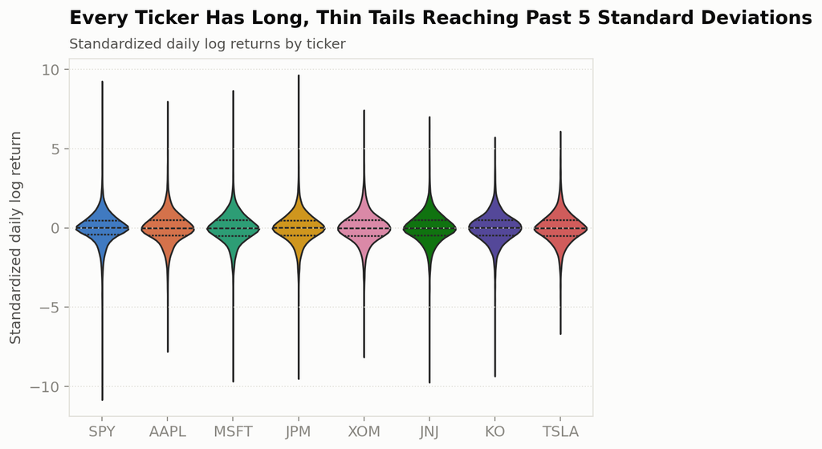

Figure 10: Standardized daily log returns by ticker

```python
fig, ax = plt.subplots()
sns.violinplot(
    data=returns_ridgeline, x="ticker", y="standardized_return", order=TICKERS,
    hue="ticker", palette=TICKER_COLORS, legend=False, inner="quartile", cut=0, ax=ax,
)
ax.set_xlabel(None)
ax.set_ylabel("Standardized daily log return")
add_title(ax, "Every Ticker Has Long, Thin Tails Reaching Past 5 Standard Deviations", "Standardized daily log returns by ticker")
fig.tight_layout()
```

Finally, the bar chart below distills each ticker’s excess kurtosis, the single number behind everything shown so far, into one ranked comparison. The result is not the one a volatility-first intuition would predict.

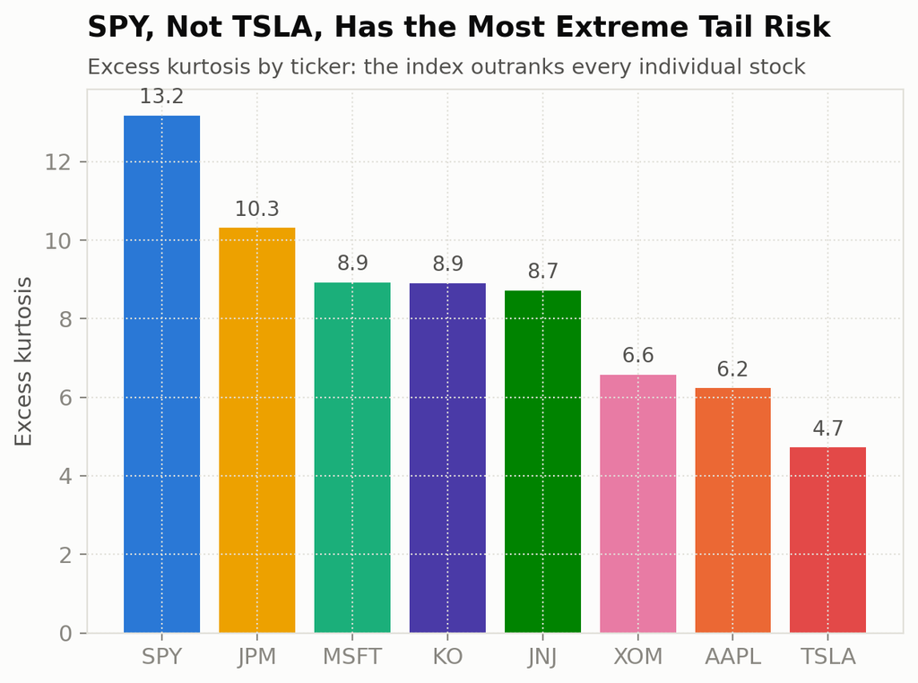

Figure 11: Excess kurtosis by ticker, sorted

```python
kurtosis_sorted = shape_table.sort_values("excess_kurtosis", ascending=False).reset_index(drop=True)

fig, ax = plt.subplots()
bars = ax.bar(
    kurtosis_sorted["ticker"], kurtosis_sorted["excess_kurtosis"],
    color=[TICKER_COLORS[t] for t in kurtosis_sorted["ticker"]],
)
for bar, value in zip(bars, kurtosis_sorted["excess_kurtosis"]):
    ax.text(bar.get_x() + bar.get_width() / 2, bar.get_height() + 0.2, f"{value:.1f}", ha="center", va="bottom", fontsize=10, color=COLOR_SECONDARY_INK)
ax.set_ylabel("Excess kurtosis")
add_title(ax, "SPY, Not TSLA, Has the Most Extreme Tail Risk", "Excess kurtosis by ticker: the index outranks every individual stock")
fig.tight_layout()
```

SPY has the highest excess kurtosis of all 8 tickers at 13.2, ahead of every individual stock including TSLA, which has the lowest at 4.7. This runs against the intuition that a single volatile stock should have the fattest tails; TSLA’s high day-to-day volatility (see the summary statistics table in Section 2) is spread more evenly across many large moves, while SPY’s crashes concentrate into a small number of extraordinarily large single-day moves, like 2020-03-16, that a market-wide index is more exposed to than any one company. High volatility and fat tails are related but distinct properties, and this ranking is the clearest evidence in the report that they do not always move together.

## 5 Volatility Clustering

An iid-normal assumption implies constant volatility: today’s variance is drawn from the same distribution as tomorrow’s, independent of what happened yesterday. This section tests and visualizes whether that holds. Engle’s ARCH-LM test (Engle 1982) formalizes the question directly, testing whether squared returns are autocorrelated, which is exactly what “volatility depends on its own recent past” means in statistical terms.

**NoteWhat is the ARCH-LM test?**

ARCH-LM (Engle’s Lagrange Multiplier test) checks for autocorrelation in a series’ squared values, which is what it means, statistically, for volatility to depend on its own recent past. It works by fitting

$$\varepsilon_t^2 = \alpha_0 + \alpha_1 \varepsilon_{t-1}^2 + \cdots + \alpha_p \varepsilon_{t-p}^2 + v_t$$

on the return series’ residuals $\varepsilon_t$ ($p = 10$ lags here) and testing whether the $\alpha_1, \ldots, \alpha_p$ coefficients are jointly zero. A large test statistic and small p-value reject that null, meaning past squared returns do help predict today’s squared return, the definition of an ARCH effect.

```python
spy_series = returns.loc[returns["ticker"] == "SPY"].sort_values("date").set_index("date")["log_return"]

lm_stat, lm_pvalue, f_stat, f_pvalue = het_arch(spy_series, nlags=10)
arch_lm_table = pd.DataFrame([{
    "lm_statistic": lm_stat, "lm_p_value": lm_pvalue,
    "f_statistic": f_stat, "f_p_value": f_pvalue,
}])

style_table(arch_lm_table, formats={
    "lm_statistic": "{:.1f}", "lm_p_value": "{:.2e}",
    "f_statistic": "{:.1f}", "f_p_value": "{:.2e}",
})
```

Table 5: Engle’s ARCH-LM test on SPY daily log returns (10 lags)

| lm_statistic | lm_p_value | f_statistic | f_p_value |
| --- | --- | --- | --- |
| 1163.8 | 9.37e-244 | 164.7 | 1.02e-289 |

Both the LM and F versions of the test reject the null of no ARCH effects at any conventional threshold (p far below 0.001). SPY’s squared returns are autocorrelated: large moves are statistically likely to be followed by more large moves, regardless of direction. The chart below shows what that looks like as a time series, SPY’s 21-day rolling annualized volatility across the full window.

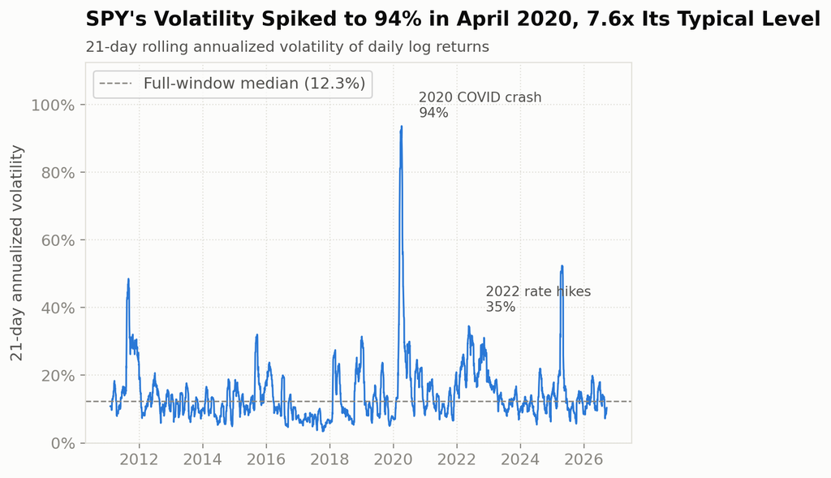

Figure 12: SPY 21-day rolling annualized volatility

```python
spy_rolling_vol = spy_series.rolling(21).std() * np.sqrt(252)
peak_2020_date, peak_2020_val = spy_rolling_vol["2020"].idxmax(), spy_rolling_vol["2020"].max()
peak_2022_date, peak_2022_val = spy_rolling_vol["2022"].idxmax(), spy_rolling_vol["2022"].max()

fig, ax = plt.subplots()
ax.plot(spy_rolling_vol.index, spy_rolling_vol, color=TICKER_COLORS["SPY"], linewidth=1.2)
ax.axhline(spy_rolling_vol.median(), color=COLOR_MUTED, linestyle="--", linewidth=1, label="Full-window median (12.3%)")
ax.annotate(f"2020 COVID crash\n{peak_2020_val:.0%}", xy=(peak_2020_date, peak_2020_val), xytext=(12, 6), textcoords="offset points", fontsize=9.5, color=COLOR_SECONDARY_INK)
ax.annotate(f"2022 rate hikes\n{peak_2022_val:.0%}", xy=(peak_2022_date, peak_2022_val), xytext=(12, 10), textcoords="offset points", fontsize=9.5, color=COLOR_SECONDARY_INK)
ax.set_ylim(0, spy_rolling_vol.max() * 1.2)
ax.yaxis.set_major_formatter(mticker.PercentFormatter(xmax=1))
ax.set_ylabel("21-day annualized volatility")
ax.legend(loc="upper left")
add_title(ax, "SPY's Volatility Spiked to 94% in April 2020, 7.6x Its Typical Level", "21-day rolling annualized volatility of daily log returns")
fig.tight_layout()
```

The point of the ARCH-LM test is that this clustering is itself predictable from recent history, not just visible in hindsight. A GARCH(1,1) model (Bollerslev 1986), fit here on SPY only as a single illustrative example rather than a full model comparison, lets volatility depend on yesterday’s shock and yesterday’s variance. The chart below overlays its conditional volatility against the realized rolling volatility from above.

**NoteWhat is a GARCH(1,1) model?**

GARCH(1,1) (Generalized AutoRegressive Conditional Heteroskedasticity) models today’s variance as a weighted combination of three things: a long-run baseline level, yesterday’s squared shock, and yesterday’s variance itself:

$$\sigma_t^2 = \omega + \alpha\, \varepsilon_{t-1}^2 + \beta\, \sigma_{t-1}^2$$

$\omega$ is the baseline variance level, $\alpha$ is how much yesterday’s surprise $\varepsilon_{t-1}^2$ moves today’s variance, and $\beta$ is how much volatility persists on its own from $\sigma_{t-1}^2$. The sum $\alpha + \beta$ measures persistence: the closer it is to 1, the more slowly a volatility shock decays. In the SPY fit used here, $\alpha \approx 0.17$ and $\beta \approx 0.79$, so $\alpha + \beta \approx 0.96$, which is why a single day of memory in each direction reproduces most of the clustering pattern visible in the realized volatility chart above.

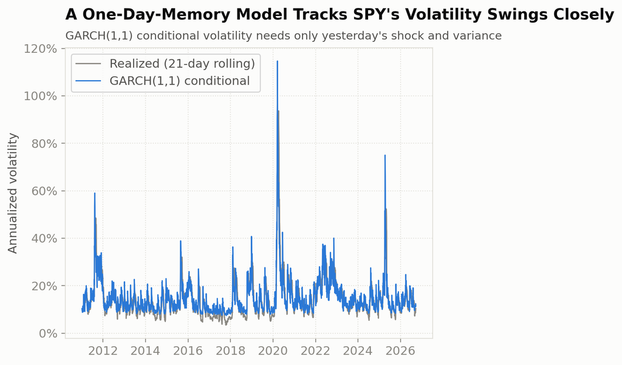

Figure 13: SPY realized rolling volatility vs. GARCH(1,1) conditional volatility

```python
garch_model = arch_model(spy_series * 100, vol="Garch", p=1, q=1, dist="normal")
garch_result = garch_model.fit(disp="off")
garch_cond_vol = garch_result.conditional_volatility / 100 * np.sqrt(252)

fig, ax = plt.subplots()
ax.plot(spy_rolling_vol.index, spy_rolling_vol, color=COLOR_MUTED, linewidth=1.1, label="Realized (21-day rolling)")
ax.plot(garch_cond_vol.index, garch_cond_vol, color=TICKER_COLORS["SPY"], linewidth=1.1, label="GARCH(1,1) conditional")
ax.yaxis.set_major_formatter(mticker.PercentFormatter(xmax=1))
ax.set_ylabel("Annualized volatility")
ax.legend(loc="upper left")
add_title(ax, "A One-Day-Memory Model Tracks SPY's Volatility Swings Closely", "GARCH(1,1) conditional volatility needs only yesterday's shock and variance")
fig.tight_layout()
```

The fitted model’s persistence parameters, $\alpha \approx 0.17$ and $\beta \approx 0.79$, sum to $\alpha + \beta \approx 0.96$: today’s variance is a weighted blend of yesterday’s shock and yesterday’s variance, and that blend barely decays, which is why the conditional volatility line tracks the realized line’s spikes and calm periods so closely without ever seeing tomorrow’s return. This is the concrete mechanism behind “volatility clustering”: a model using only one lag of memory reproduces most of the pattern an iid-normal assumption says should not exist at all.